# R Notebook

### Hierarchical Clustering

organize your data in a hiearchical order

- find closest two things
- put them together
- find next closest

produces a tree showing how close things

- Defining Closeness
- distance or similarity
  - continuous euclidean space
  - continuous correlation similarity
  - binary - Manhattan distance

Euclidean Distance- fly over distance

$\sqrt{(x_{1} - x_{2})^2 + (y_{1} - y_{2})^2}$

Manhattan distance:

Considering roads in a city when you calculate a distance

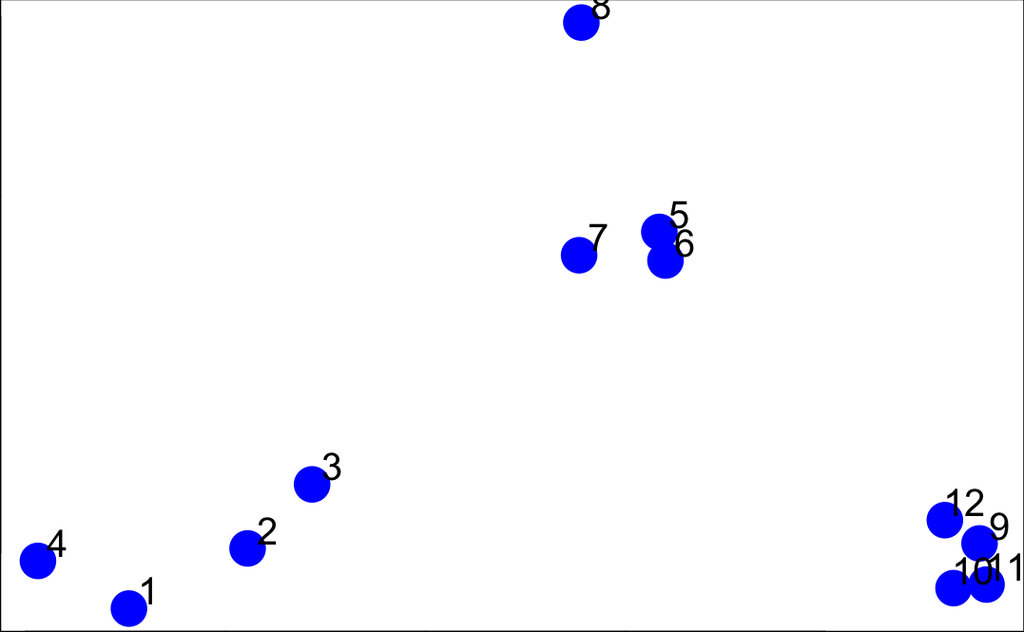

```r
set.seed(1234)
par(mar = c(0,0,0,0))
x <- rnorm(12, mean = rep(1:3, each = 4), sd = 0.2)
y <- rnorm(12, mean = rep(c(1, 2, 1), each = 4), sd = 0.2)
plot(x, y, col = "blue", pch =19, cex = 2)
text(x + 0.05, y + 0.05, labels = as.character(1:12))
```

# Calculating distance

This function computes and returns the distance matrix computed by using the specified distance measure to compute the distances between the rows of a data matrix.

```r
str(dist)
```

```
function (x, method = "euclidean", diag = FALSE, upper = FALSE, p = 2)
```

```r
df <- data.frame(x = x, y=y)
dist(df)
```

```
            1          2          3          4          5          6          7          8          9
2  0.34120511
3  0.57493739 0.24102750
4  0.26381786 0.52578819 0.71861759
5  1.69424700 1.35818182 1.11952883 1.80666768
6  1.65812902 1.31960442 1.08338841 1.78081321 0.08150268
7  1.49823399 1.16620981 0.92568723 1.60131659 0.21110433 0.21666557
8  1.99149025 1.69093111 1.45648906 2.02849490 0.61704200 0.69791931 0.65062566
9  2.13629539 1.83167669 1.67835968 2.35675598 1.18349654 1.11500116 1.28582631 1.76460709
10 2.06419586 1.76999236 1.63109790 2.29239480 1.23847877 1.16550201 1.32063059 1.83517785 0.14090406
11 2.14702468 1.85183204 1.71074417 2.37461984 1.28153948 1.21077373 1.37369662 1.86999431 0.11624471
12 2.05664233 1.74662555 1.58658782 2.27232243 1.07700974 1.00777231 1.17740375 1.66223814 0.10848966
           10         11
2
3
4
5
6
7
8
9
10
11 0.08317570
12 0.19128645 0.20802789
```

```r
str(hclust)
```

```
function (d, method = "complete", members = NULL)
```

Hierarchical cluster analysis on a set of dissimilarities and methods for analyzing it.

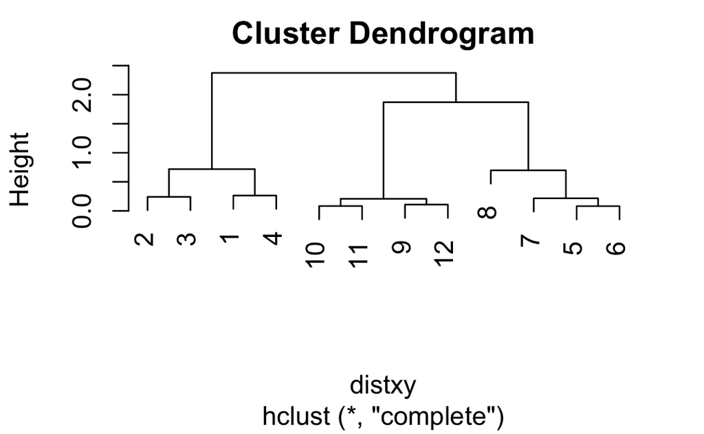

```r
distxy <- dist(df)
hClustering <- hclust(distxy)
plot(hClustering)
```

```r
myplclust <- function(hclust, lab = hclust$labels,
                      lab.col = rep(1, length(hclust$labels)),
                      hang = 0.1, ...) {
# modification of plclust for plotting hclust objects *in colour*! copyright
# Eva KF Chan 2009 Arguments: hclust: object lab: a character vector
# of labels of the leaves of the tree lab.col: colour for the labels;
# NA = default device foreground colour hang: as in hclust & plclust Side
# effect: A display of hierarchical cluster with coloured leaf labels.
    y <- rep(hclust$height, 2)
    x <- as.numeric(hclust$merge)
    y <- y[which(x < 0)]
    x <- x[which(x < 0)]
    x <- abs(x)
    y <- y[order(x)]
    x <- x[order(x)]
    plot(hclust, labels = FALSE, hang = hang, ...)
    text(x = x, y = y[hclust$order] - (max(hclust$height) * hang),
         labels = lab[hclust$order], col = lab.col[hclust$order],
         srt = 90, adj = c(1, 0.5), xpd = NA, ...)
    }
```

You have to know the number of clusters before yoou draw the dendrogram

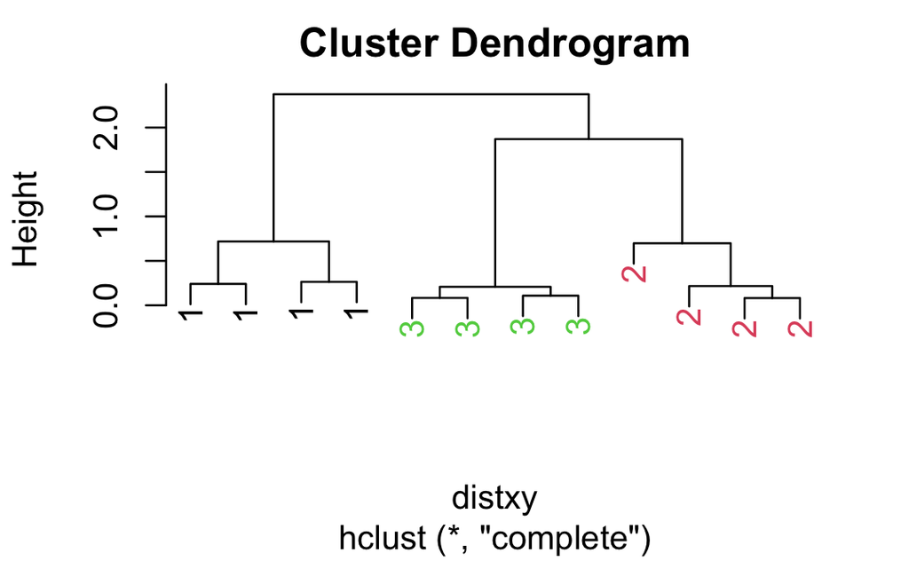

```r
myplclust(hClustering, lab = rep(1:3, each = 4),
          lab.col = rep(1:3, each = 4))
```

In R graph Gallery, you can find more graph options.

# merging the points

what represents the new locations? 1. you can merge taking average of axis, distances 2. complete linkage

both can result differently.

### Heatmap() function

the Idea here is that, heatmap function uses clusters

reorder the columns and row according to the groups

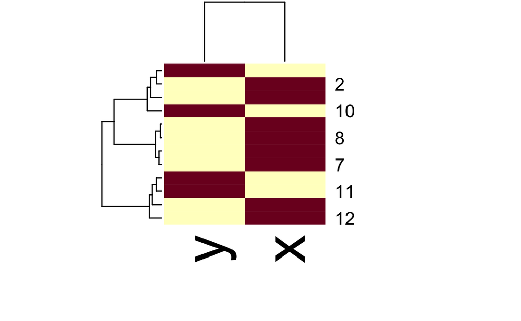

```r
x <- rnorm(12, mean = rep(1:3, each = 4), sd = 0.2)
y <- rnorm(12, mean = rep(c(1, 2, 1), each = 4), sd = 0.2)
df <- data.frame(x = x, y = y)

set.seed(143)
dataMatrix <- as.matrix(df)[sample(1:12), ]
heatmap(dataMatrix)
```

```r
NA
NA
```

### Summary

- Gives an idea of the relationaship between variables/observations
- the picture may be unstable
- Should be primarily used for exploration
- Some variables may need to be rescaled

### K-Means Clustering

- what does it means to be close?

#### An Example

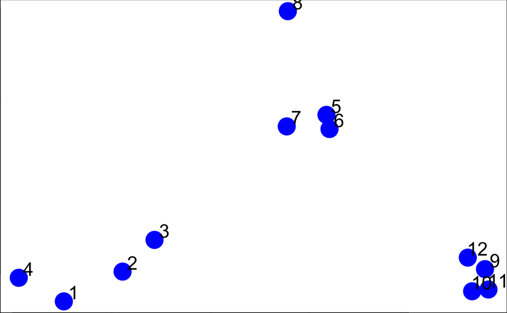

```r
set.seed(1234)
par(mar = c(0,0,0,0))

x <- rnorm(12, mean = rep(1:3, each = 4), sd = 0.2)
y <- rnorm(12, mean = rep(c(1, 2, 1), each = 4), sd = 0.2)

plot(x, y, col = "blue", pch = 19, cex = 2)
text(x + 0.05, y + 0.05, labels = as.character(1:12))
```

### Kmeans()

You need to specify number of clusters - pick by eye/intuition - pick by cross validation/information theory - determine the number of clusters

K-means is not deterministic - different # of clusters - different number of iterations

```r
df <- data.frame(x, y)
kmeansobj <- kmeans(df, centers = 3)
names(kmeansobj)
```

```
[1] "cluster"      "centers"      "totss"        "withinss"     "tot.withinss" "betweenss"
[7] "size"         "iter"         "ifault"
```

```r
kmeansobj$cluster
```

```
 [1] 3 1 1 3 2 2 2 2 2 2 2 2
```

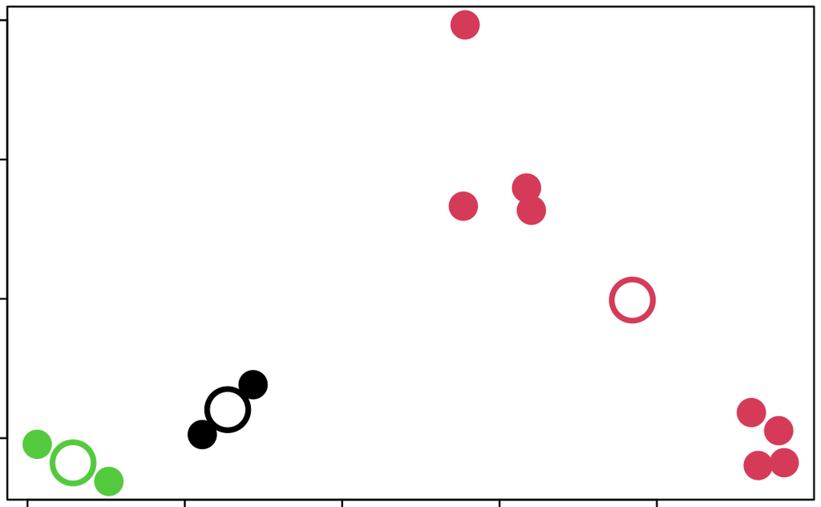

```r
par(mar = rep(0.2, 4))

plot(x, y, col = kmeansobj$cluster, pch = 19, cex = 2)
points(kmeansobj$centers, col = 1:3, cex = 3, lwd = 3)
```

### Heatmap()

Another way to see clusters

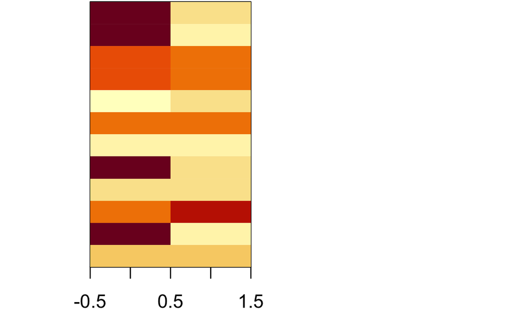

```r
set.seed(1234)
dataMatrix <- as.matrix(df)[sample(1:12), ]

kmeansobj <- kmeans(dataMatrix, centers = 3)
par(mfrow = c(1, 2), mar = c(2, 4, 0.1, 0.1))

image(t(dataMatrix)[, nrow(dataMatrix):1], yaxt = "n")
image(t(dataMatrix)[, order(kmeansobj$cluster)], yaxt = "n")
```

## Summary

- K-means requires a number of clusters
  - pick by intuition
  - pick by cross validation
- K-means is not deterministic
  - Different number of clusters
  - different number of iterations

### Example

Our goal is to show you how to use exploratory data analysis to point you in fruitful directions of research, that is, towards answerable questions. Exploratory data analysis is a “rough cut” or filter which helps you to find the most beneficial areas of questioning so you can set your priorities accordingly.

We also hope to show you that “real-world” research isn’t always neat and well-defined like textbook questions with clearcut answers.

We’ve loaded data from this study for you in a matrix called ssd. Run the R command dim now to see its dimensions.

```r
library(readxl)
samsungData <- read.csv("./data/samsungdata.csv")
```

```r
names(samsungData)[1:12]
```

```
 [1] "tBodyAcc.mean...X" "tBodyAcc.mean...Y" "tBodyAcc.mean...Z"
 [4] "tBodyAcc.std...X"  "tBodyAcc.std...Y"  "tBodyAcc.std...Z"
 [7] "tBodyAcc.mad...X"  "tBodyAcc.mad...Y"  "tBodyAcc.mad...Z"
[10] "tBodyAcc.max...X"  "tBodyAcc.max...Y"  "tBodyAcc.max...Z"
```

```r
table(samsungData$activity)
```

```
  laying  sitting standing     walk walkdown   walkup
    1407     1286     1374     1226      986     1073
```

```r
dim(samsungData)
```

```
[1] 7352  563
```

Wow - ssd is pretty big, 7352 observations, each of 563 variables. Don’t worry we’ll only use a small portion of this “Human Activity Recognition database”.

The study creating this database involved 30 volunteers "performing activities of daily living (ADL) while carrying a waist-mounted smartphone with embedded inertial sensors. … Each person performed six activities … wearing a smartphone (Samsung Galaxy S II) on the waist. … The experiments have been video-recorded to label the data manually.

The obtained dataset has been randomly partitioned into two sets, where 70% of the volunteers was selected for generating the training data and 30% the test data."

Use the R command names with just the last two columns (562 and 563) of ssd to see what data they contain.

```r
names(samsungData[562:563])
```

These last 2 columns contain subject and activity information. We saw above that the gathered data had “been randomly partitioned into two sets, where 70% of the volunteers was selected for generating the training data and 30% the test data.” Run the R command table with ssd$subject as its argument to see if the data in ssd contains training or test data.

```r
table(samsungData$subject)
```

Try it now (running sum on table(ssd$subject))to see if you get 7352, the number of rows in ssd, as a result.

```r
sum(table(samsungData$subject))
```

So we’re looking at training data from a machine learning repository. We can infer that this data is supposed to train machines to recognize activity collected from the accelerometers and gyroscopes built into the smartphones that the subjects had strapped to their waists. Run the R command table on ssd$activity to see what activities have been characterized by this data.

We have 6 activities, 3 passive (laying, standing and sitting) and 3 active which involve walking. If you ran the R command sum with table(ssd$activity) as its argument, what would the number you get back represent?

```r
sum(table(samsungData$activity) )
```

Because it’s training data, each row is labeled with the correct activity (from the 6 possible) and associated with the column measurements (from the accelerometer and gyroscope). We’re interested in questions such as, “Is the correlation between the measurements and activities good enough to train a machine?” so that “Given a set of 561 measurements, would a trained machine be able to determine which of the 6 activities the person was doing?”

First, let’s massage the data a little so it’s easier to work with. We’ve already run the R command transform on the data so that activities are factors. This will let us color code them when we generate plots. Let’s look at only the first subject (numbered 1). Create the variable sub1 by assigning to it the output of the R command subset with ssd as the first argument and the boolean, subject equal to 1, as the second.

## Plotting Average Acceleration

```r
par(mfrow = c(1, 2), mar = c(5, 4, 1, 1))
samsungData <- transform(samsungData, activity = factor(activity))
sub1 <- subset(samsungData, subject ==1)
dim(sub1)
```

```
[1] 347 563
```

```r
par(mfrow = c(1, 2), mar = c(5, 4, 1, 1))
plot(sub1[, 1], col = sub1$activity, ylab = names(sub1)[1])
plot(sub1[, 2], col = sub1$activity, ylab = names(sub1)[2])
```

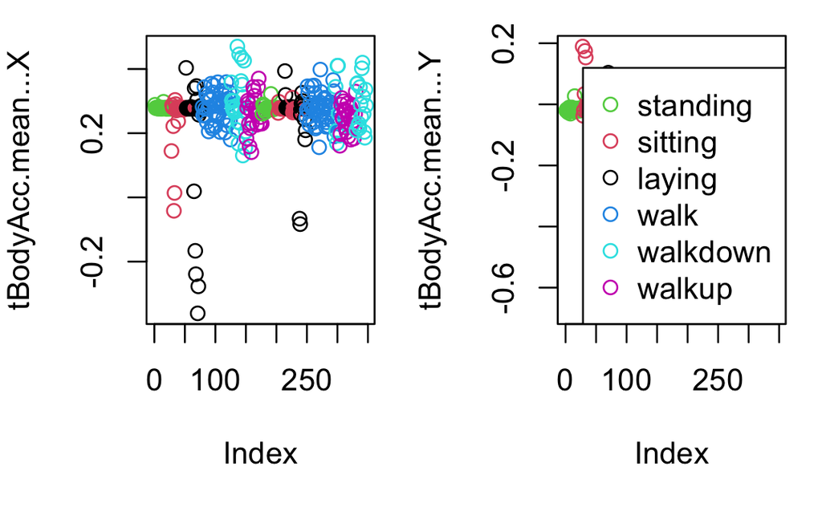

```r
legend("bottomright", legend = unique(sub1$activity),
       col = unique(sub1$activity), pch = 1)
```

So sub1 has fewer than 400 rows now, but still a lot of columns which contain measurements. Use names on the first 12 columns of sub1 to see what kind of data we have.

```r
names(sub1[, 1:12])
```

We see X, Y, and Z (3 dimensions) of different aspects of body acceleration measurements, such as mean and standard deviation. Let’s do some comparisons of activities now by looking at plots of mean body acceleration in the X and Y directions. Call the function myedit with the string “showXY.R” to see the code generating the plots. Make sure your cursor is back in the console window before you hit any more buttons.

```r
myedit("showXY.R")
```

The colors are a little hard to distinguish. Just for fun, call the function showMe (we used it in the Working_with_Colors lesson) which displays color vectors. Use the vector 1:6 as its argument, and hopefully this will clarify the colors you see in the XY comparison plot.

We’ll still focus on the 3 dimensions of mean acceleration. (The plot we just saw looked at the first 2 dimensions.) Create a distance matrix, mdist, of the first 3 columns of sub1, by using the R command dist. Use the x[,1:3] notation to specify the columns.

### Clustering based on average acceleration

```r
mdist <- dist(sub1[, 1:3])
```

Now create the variable hclustering by calling the R command hclust and passing it mdist as an argument. This will use the Euclidean distance as its default metric.

```r
hclustering <- hclust(mdist)

myplclust(hclustering, lab.col = unclass(sub1$activity))
```

[output not shown]

Finally we’re seeing something vaguely interesting! Let’s focus then on the 3 dimensions of maximum acceleration, stored in columns 10 through 12 of sub1. Create a new distance matrix, mdist, of these 3 columns of sub1, by using the R command dist. Again, use the x[,10:12] notation to catch the columns.

### Plot max accelaeration for first subject

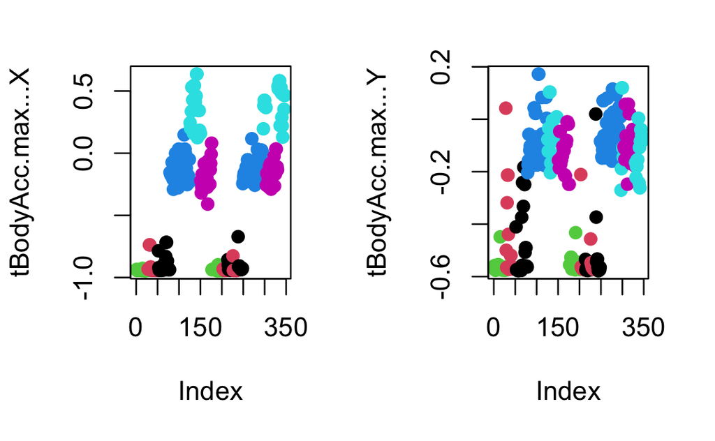

```r
par(mfrow = c(1, 2))
plot(sub1[, 10], pch = 19, col = sub1$activity, ylab = names(sub1)[10])
plot(sub1[, 11], pch = 19, col = sub1$activity, ylab = names(sub1)[11])
```

### Clustering max acceleration for first subject

```r
source("./functions/myplclust.R")
distancematrix <- dist(sub1[, 10:12])
```

Now create the variable hclustering by calling hclust with mdist as the argument.

```r
hclustering <- hclust(distancematrix)
```

Again, call the myplclust with 2 arguments. The first is hclustering, and the second is the argument lab.col set equal to unclass(sub1$activity).

```r
myplclust(hclustering, lab.col = unclass(sub1$activity))
```

### Singular Value Decomposition

Let’s try some SVD now. Create the variable svd1 by assigning to it the output of a call to the R command svd. The argument to svd should be scale(sub1[,-c(562,563)]). This will remove the last 2 columns from sub1 and scale the data. Recall that the last 2 columns contain activity and subject information which we won’t need.

```r
svd1 <- svd(scale(sub1[,-c(562,563)]))
```

To see LEFT singular vectors of sub1, which component of svd1 would we examine?

```r
dim(svd1$u)
```

```r
par(mfrow = c(1, 2))
plot(svd1$u[, 1], col = sub1$activity, pch = 19)
plot(svd1$u[, 2], col = sub1$activity, pch = 19)
```

#### Find maximum contributer

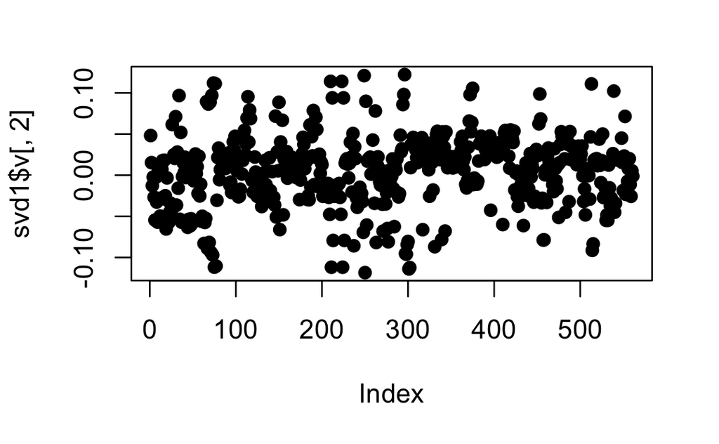

```r
plot(svd1$v[, 2], pch = 19)
```

Create the variable maxCon by assigning to it the output of the R command which.max using the second column of svd1$v as an argument.

```r
maxCon <- which.max(svd1$v[,2])
```

Now create a distance matrix mdist by assigning to it the output of the R command dist using 4 columns of sub1 as the arguments. These 4 columns are 10 through 12 (10:12) and maxCon. Recall that you’ll have to concatenate these 2 column expressions when specifying them.

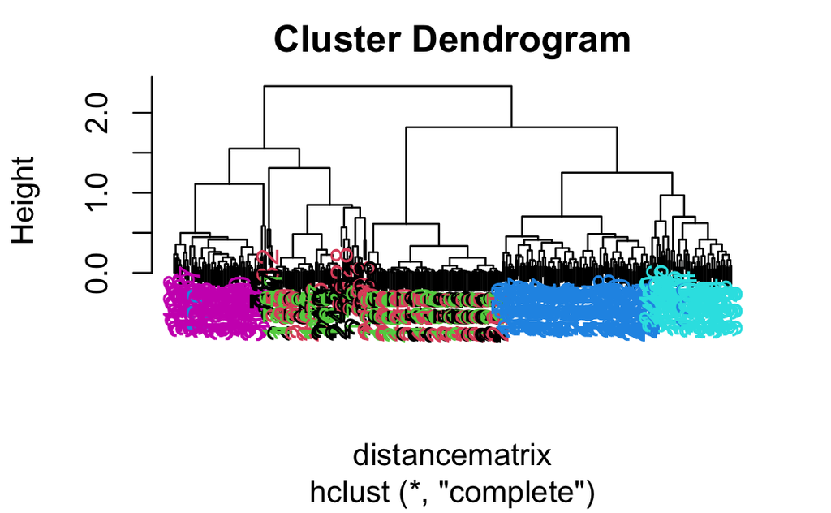

```r
distancematrix <- dist(sub1[, c(10:12, maxCon)])

hclustering <- hclust(distancematrix)

myplclust(hclustering, lab.col = unclass(sub1$activity))
```

Now we see some real separation. Magenta (walking up) is on the far left, and the two other walking activities, the two blues, are on the far right, but in separate clusters from one another. The nonmoving activities still are jumbled together.

Run the R command names with the argument sub1[maxCon] to see what measurement is associated with this maximum contributor.

```r
names(sub1[maxCon])
```

```
[1] "fBodyAcc.meanFreq...Z"
```

### K-means Clustering (nstart = 1, first try)

So the mean body acceleration in the frequency domain in the Z direction is the main contributor to this clustering phenomenon we’re seeing. Let’s move on to k-means clustering to see if this technique can distinguish between the activities.

Create the variable kClust by assigning to it the output of the R command kmeans with 2 arguments. The first is sub1 with the last 2 columns removed. (Recall these don’t have pertinent information for clustering analysis.) The second argument to kmeans is centers set equal to 6, the number of activities we know we have.

```r
 kClust <- kmeans(sub1[, -c(562:563)], centers = 6 )
```

Recall that without specifying coordinates for the cluster centroids (as we did), kmeans will generate starting points randomly. Here we did only 1 random start (the default). To see the output, run the R command table with 2 arguments. The first is kClust$cluster (part of the output from kmeans), and the second is sub1$activity.

```r
table(kClust$cluster, sub1$activity )
```

```
    laying sitting standing walk walkdown walkup
  1      8       2        0    0        0     53
  2      0       0        0   50        0      0
  3      0       0        0    0       23      0
  4      0       0        0   45        0      0
  5      0       0        0    0       26      0
  6     42      45       53    0        0      0
```

Your exact output will depend on the state of your random number generator. We notice that when we just run with 1 random start, the clusters tend to group the nonmoving activities together in one cluster. The walking activities seem to cluster individually by themselves. You could run the call to kmeans with one random start again and you’ll probably get a slightly different result, but….

… instead call kmeans with 3 arguments, the last of which will tell it to try more random starts and return the best one. The first 2 arguments should be the same as before (sub1 with the last 2 columns removed and centers set equal to 6). The third is nstart set equal to 100. Put the result in kClust again.

```r
kClust <- kmeans(sub1[, -c(562:563)], centers = 6,
                 nstart = 100 )

table(kClust$cluster, sub1$activity )
```

```
    laying sitting standing walk walkdown walkup
  1     18      10        2    0        0      0
  2      0       0        0   95        0      0
  3      0      37       51    0        0      0
  4      0       0        0    0       49      0
  5      3       0        0    0        0     53
  6     29       0        0    0        0      0
```

We see that even with 100 random starts, the passive activities tend to cluster together. One of the clusters contains only laying, but in another cluster, standing and sitting group together.

Use dim to find the dimensions of kClust’s centers. Use the x$y notation to access them.

```r
dim(kClust$centers)
```

Sometimes it’s a good idea to look at the features (columns) of these centers to see if any dominate.

Create the variable laying and assign to it the output of the call to the R command which with the argument kClust$size==29.

```r
laying <- which(kClust$size==29)
```

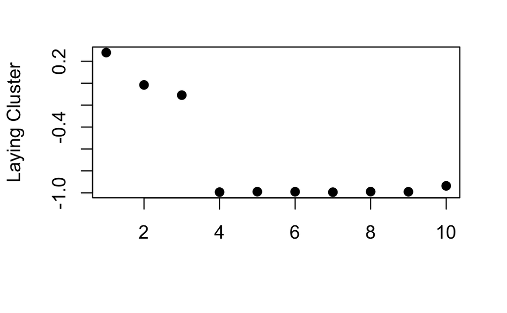

```r
plot(kClust$centers[laying,1:10], pch = 19, ylab = "Laying Cluster", xlab = "")
```

We see the first 3 columns dominate this cluster center. Run names with the first 3 columns of sub1 as the argument to remind yourself of what these columns contain.

```r
names(sub1[, 1:3])
```

So the 3 directions of mean body acceleration seem to have the biggest effect on laying.

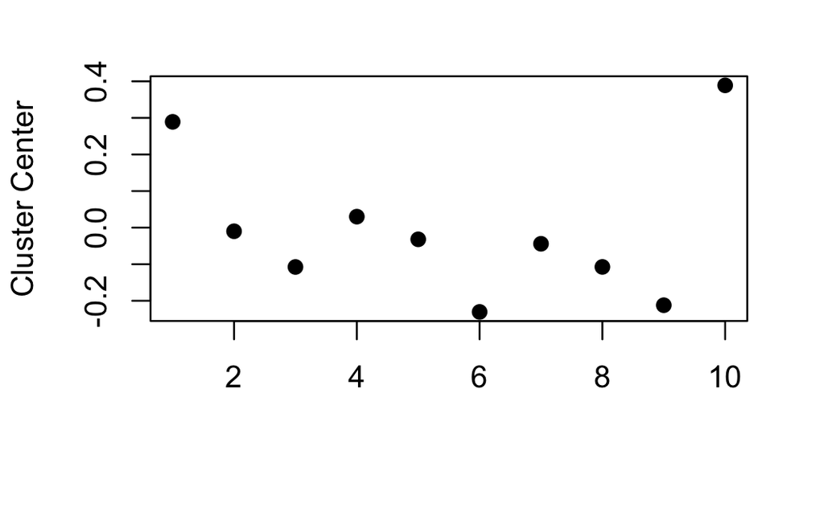

```r
plot(kClust$centers[4, 1:10], pch = 19, ylab = "Cluster Center", xlab = "")
```

Create the variable walkdown and assign to it the output of the call to the R command which with the argument kClust$size==49.

```r
walkdown <- which(kClust$size==49)
```

Now call plot with 3 arguments. The first is kClust$centers[walkdown,1:12], and the second is pch set to 19. The third is ylab set equal to “Walkdown Cluster”

```r
plot(kClust$centers[walkdown,1:12], pch = 19, ylab = "Walkdown Cluster")
```

[output not shown]

We’ll wrap up here and hope this example convinced you that real world analysis can be frustrating sometimes and not always obvious. You might have to try several techniques of exploratory data analysis before you hit one that pays off and leads you to the questions that will be the most promising to explore.

We saw here that the sensor measurements were pretty good at discriminating between the 3 walking activities, but the passive activities were harder to distinguish from one another. These might require more analysis or an entirely different set of sensory measurements.